# Assignment-Two

2022-10-20

## U7117486 Assignment Two

### Load in packages

```r
library(pacman)
p_load(bookdown, tidyverse, ggforce, flextable, latex2exp, png, magick, metafor)
```

### Reading in the csv file

```r
data <- read_csv("OA_activitydat_20190302_BIOL3207.csv")
```

```
## ──────────────────────────────────────────────────────── Delimiter: "," chr
## (5): loc, species, treatment, size, comment dbl (4): ...1, animal_id, sl,
## activity
```

```r
data
```

```
## # A tibble: 589 × 9
##     ...1 loc       species treatment animal_id    sl size  activity comment
##    <dbl> <chr>     <chr>   <chr>         <dbl> <dbl> <chr>    <dbl> <chr>
##  1     1 LIRS 2014 ambon   CO2              64  57.0 big       8.15 27min means…
##  2     2 LIRS 2014 ambon   CO2              65  38.2 big      10.5  27min means…
##  3     3 LIRS 2014 ambon   CO2              67  39.3 big       6.51 27min means…
##  4     4 LIRS 2014 ambon   CO2              68  36.1 big      27.8  27min means…
##  5     5 LIRS 2014 lemon   CO2              74  36.4 big      36.7  27min means…
##  6     6 LIRS 2014 ambon   CO2              75  35.9 big      42.8  27min means…
##  7     7 LIRS 2014 lemon   CO2              81  35.7 big      21.9  27min means…
##  8     8 LIRS 2014 ambon   CO2              84  38.4 big      24.6  27min means…
##  9     9 LIRS 2014 ambon   CO2             222  34   big      NA    recording f…
## 10    10 LIRS 2014 ambon   CO2              85  48.3 big      35.1  27min means…
## # … with 579 more rows
## # ℹ Use `print(n = ...)` to see more rows
```

### Omitting N/A data

```r
data <- na.omit(data)
data
```

```
## # A tibble: 550 × 9
##     ...1 loc       species treatment animal_id    sl size  activity comment
##    <dbl> <chr>     <chr>   <chr>         <dbl> <dbl> <chr>    <dbl> <chr>
##  1     1 LIRS 2014 ambon   CO2              64  57.0 big       8.15 27min means…
##  2     2 LIRS 2014 ambon   CO2              65  38.2 big      10.5  27min means…
##  3     3 LIRS 2014 ambon   CO2              67  39.3 big       6.51 27min means…
##  4     4 LIRS 2014 ambon   CO2              68  36.1 big      27.8  27min means…
##  5     5 LIRS 2014 lemon   CO2              74  36.4 big      36.7  27min means…
##  6     6 LIRS 2014 ambon   CO2              75  35.9 big      42.8  27min means…
##  7     7 LIRS 2014 lemon   CO2              81  35.7 big      21.9  27min means…
##  8     8 LIRS 2014 ambon   CO2              84  38.4 big      24.6  27min means…
##  9    10 LIRS 2014 ambon   CO2              85  48.3 big      35.1  27min means…
## 10    11 LIRS 2014 ambon   CO2              88  43.4 big       1.02 27min means…
## # … with 540 more rows
## # ℹ Use `print(n = ...)` to see more rows
```

### Drop irrelevant columns

```r
data <- subset(data, select = -c(comment, loc))
data
```

```
## # A tibble: 550 × 7
##     ...1 species treatment animal_id    sl size  activity
##    <dbl> <chr>   <chr>         <dbl> <dbl> <chr>    <dbl>
##  1     1 ambon   CO2              64  57.0 big       8.15
##  2     2 ambon   CO2              65  38.2 big      10.5
##  3     3 ambon   CO2              67  39.3 big       6.51
##  4     4 ambon   CO2              68  36.1 big      27.8
##  5     5 lemon   CO2              74  36.4 big      36.7
##  6     6 ambon   CO2              75  35.9 big      42.8
##  7     7 lemon   CO2              81  35.7 big      21.9
##  8     8 ambon   CO2              84  38.4 big      24.6
##  9    10 ambon   CO2              85  48.3 big      35.1
## 10    11 ambon   CO2              88  43.4 big       1.02
## # … with 540 more rows
## # ℹ Use `print(n = ...)` to see more rows
```

### Creating a summary of results

```r
summary1<- filter(data, treatment == "control") %>% group_by(species) %>% summarise(mean(activity), sd(activity), n())
colnames(summary1) <- c("Species", "ctrl.mean", "ctrl.sd", "ctrl.n")

summary2<- filter(data, treatment == "CO2") %>% group_by(species) %>% summarise(mean(activity), sd(activity), n())
colnames(summary2) <- c("Species", "oa.mean", "oa.sd", "oa.n")

summary <- merge(summary1, summary2)
summary
```

```
##     Species ctrl.mean   ctrl.sd ctrl.n  oa.mean     oa.sd oa.n
## 1   acantho  28.92639 11.246347     90 27.30042 10.415559   86
## 2     ambon  17.34102 11.451588     21 18.39429 12.200326   22
## 3   chromis  26.09986  9.125352     20 24.78010 10.975005   14
## 4    humbug  34.91652 13.867278     65 40.28306 11.915992   62
## 5     lemon  19.79766 12.256353     30 26.04157 10.957164   19
## 6 whitedams  26.58624 10.936592     61 24.45733  9.950437   60
```

### Reading in the clark paper meta data

```r
clark_meta <- read_csv("clark_paper_data.csv")
clark_meta
```

```
## # A tibble: 1 × 15
##   Study Authors    Year …¹ Year …² Title Journal Pub y…³ 2017 …⁴ Avera…⁵ Effec…⁶
##   <chr> <chr>        <dbl>   <dbl> <chr> <chr>     <dbl>   <dbl>   <dbl> <chr>
## 1 a92   Clark et …    2020    2020 Ocea… Nature     69.5    41.6      45 Weak
## # … with 5 more variables: `Climate (FishBase)` <chr>,
## #   `Env cue/stimulus?` <chr>, `Cue/stimulus type` <lgl>,
## #   `Behavioural metric` <chr>, `Life stage` <chr>, and abbreviated variable
## #   names ¹`Year (online)`, ²`Year (print)`, ³`Pub year IF`, ⁴`2017 IF`,
## #   ⁵`Average n`, ⁶`Effect type`
## # ℹ Use `colnames()` to see all variable names
```

### Binding the summary results to the study information meta data provided

```r
clark_data <- bind_cols(clark_meta, summary)
clark_data
```

```
## # A tibble: 6 × 22
##   Study Authors    Year …¹ Year …² Title Journal Pub y…³ 2017 …⁴ Avera…⁵ Effec…⁶
##   <chr> <chr>        <dbl>   <dbl> <chr> <chr>     <dbl>   <dbl>   <dbl> <chr>
## 1 a92   Clark et …    2020    2020 Ocea… Nature     69.5    41.6      45 Weak
## 2 a92   Clark et …    2020    2020 Ocea… Nature     69.5    41.6      45 Weak
## 3 a92   Clark et …    2020    2020 Ocea… Nature     69.5    41.6      45 Weak
## 4 a92   Clark et …    2020    2020 Ocea… Nature     69.5    41.6      45 Weak
## 5 a92   Clark et …    2020    2020 Ocea… Nature     69.5    41.6      45 Weak
## 6 a92   Clark et …    2020    2020 Ocea… Nature     69.5    41.6      45 Weak
## # … with 12 more variables: `Climate (FishBase)` <chr>,
## #   `Env cue/stimulus?` <chr>, `Cue/stimulus type` <lgl>,
## #   `Behavioural metric` <chr>, `Life stage` <chr>, Species <chr>,
## #   ctrl.mean <dbl>, ctrl.sd <dbl>, ctrl.n <int>, oa.mean <dbl>, oa.sd <dbl>,
## #   oa.n <int>, and abbreviated variable names ¹`Year (online)`,
## #   ²`Year (print)`, ³`Pub year IF`, ⁴`2017 IF`, ⁵`Average n`, ⁶`Effect type`
## # ℹ Use `colnames()` to see all variable names
```

###Reading in the larger meta data set

```r
ocean_meta <- read_csv("ocean_meta_data.csv")
ocean_meta
```

```
## # A tibble: 818 × 22
##    Study Authors   Year …¹ Year …² Title Journal Pub y…³ 2017 …⁴ Avera…⁵ Effec…⁶
##    <chr> <chr>       <dbl>   <dbl> <chr> <chr>   <chr>   <chr>     <dbl> <chr>
##  1 a1    Munday e…    2009    2009 Ocea… PNAS    9.432   9.504        27 Strong
##  2 a1    Munday e…    2009    2009 Ocea… PNAS    9.432   9.504        27 Strong
##  3 a1    Munday e…    2009    2009 Ocea… PNAS    9.432   9.504        27 Strong
##  4 a1    Munday e…    2009    2009 Ocea… PNAS    9.432   9.504        27 Strong
##  5 a1    Munday e…    2009    2009 Ocea… PNAS    9.432   9.504        27 Strong
##  6 a1    Munday e…    2009    2009 Ocea… PNAS    9.432   9.504        27 Strong
##  7 a1    Munday e…    2009    2009 Ocea… PNAS    9.432   9.504        27 Strong
##  8 a2    Dixson e…    2009    2010 Ocea… Ecol L… 10.318  9.137        15 Strong
##  9 a2    Dixson e…    2009    2010 Ocea… Ecol L… 10.318  9.137        15 Strong
## 10 a2    Dixson e…    2009    2010 Ocea… Ecol L… 10.318  9.137        15 Strong
## # … with 808 more rows, 12 more variables: Species <chr>,
## #   `Climate (FishBase)` <chr>, `Env cue/stimulus?` <chr>,
## #   `Cue/stimulus type` <chr>, `Behavioural metric` <chr>, `Life stage` <chr>,
## #   ctrl.n <dbl>, ctrl.mean <dbl>, ctrl.sd <dbl>, oa.n <dbl>, oa.mean <dbl>,
## #   oa.sd <dbl>, and abbreviated variable names ¹`Year (online)`,
## #   ²`Year (print)`, ³`Pub year IF`, ⁴`2017 IF`, ⁵`Average n`, ⁶`Effect type`
## # ℹ Use `print(n = ...)` to see more rows, and `colnames()` to see all variable names
```

### Binding the clark data to the larger meta data set

```r
clark_data[, c(12)] <- sapply(clark_data[, c(12)], as.character)
clark_data[, c(7)] <- sapply(clark_data[, c(7)], as.character)
clark_data[, c(8)] <- sapply(clark_data[, c(8)], as.character)

merged_data <- bind_rows(ocean_meta, clark_data)

colnames(merged_data)[16] <- "Life_Stage"

# Getting rid of negative data
merged_data <- merged_data[which(merged_data$ctrl.n > 0),]
merged_data <- merged_data[which(merged_data$ctrl.mean > 0),]
merged_data <- merged_data[which(merged_data$ctrl.sd > 0),]
merged_data <- merged_data[which(merged_data$oa.n > 0),]
merged_data <- merged_data[which(merged_data$oa.mean > 0),]
merged_data <- merged_data[which(merged_data$oa.sd > 0),]

# Checking that negatives are excluded
max(merged_data$ctrl.mean,na.rm=FALSE)
```

```
## [1] 154936.9
```

```r
min(merged_data$ctrl.mean,na.rm=FALSE)
```

```
## [1] 1e-04
```

```r
max(merged_data$oa.mean,na.rm=FALSE)
```

```
## [1] 157061.2
```

```r
min(merged_data$oa.mean,na.rm=FALSE)
```

```
## [1] 1e-04
```

```r
max(merged_data$ctrl.n,na.rm=FALSE)
```

```
## [1] 752
```

```r
min(merged_data$ctrl.n,na.rm=FALSE)
```

```
## [1] 4
```

```r
max(merged_data$oa.n,na.rm=FALSE)
```

```
## [1] 755
```

```r
min(merged_data$oa.n,na.rm=FALSE)
```

```
## [1] 2
```

### Correctly calculate the log response ratio (lnRR) effect size for every row of the dataframe using metafor’s escalc() function.

```r
# Log Response Ratio (lnRR)
merged_data <- metafor::escalc(measure = "ROM",
                               m1i = ctrl.mean,
                               sd1i = ctrl.sd,
                               n1i = ctrl.n,
                               m2i = oa.mean,
                               sd2i = oa.sd,
                               n2i = oa.n,
                               data = merged_data,
                               var.names = c("lnRR", "vlnRR"))

merged_data$residual <- 1:nrow(merged_data)
```

### Assessing data in tibble

```r
tibble(merged_data)
```

```
## # A tibble: 764 × 25
##    Study Authors   Year.…¹ Year.…² Title Journal Pub.y…³ X2017…⁴ Avera…⁵ Effec…⁶
##    <chr> <chr>       <dbl>   <dbl> <chr> <chr>   <chr>   <chr>     <dbl> <chr>
##  1 a1    Munday e…    2009    2009 Ocea… PNAS    9.432   9.504        27 Strong
##  2 a1    Munday e…    2009    2009 Ocea… PNAS    9.432   9.504        27 Strong
##  3 a1    Munday e…    2009    2009 Ocea… PNAS    9.432   9.504        27 Strong
##  4 a1    Munday e…    2009    2009 Ocea… PNAS    9.432   9.504        27 Strong
##  5 a1    Munday e…    2009    2009 Ocea… PNAS    9.432   9.504        27 Strong
##  6 a1    Munday e…    2009    2009 Ocea… PNAS    9.432   9.504        27 Strong
##  7 a1    Munday e…    2009    2009 Ocea… PNAS    9.432   9.504        27 Strong
##  8 a2    Dixson e…    2009    2010 Ocea… Ecol L… 10.318  9.137        15 Strong
##  9 a2    Dixson e…    2009    2010 Ocea… Ecol L… 10.318  9.137        15 Strong
## 10 a2    Dixson e…    2009    2010 Ocea… Ecol L… 10.318  9.137        15 Strong
## # … with 754 more rows, 15 more variables: Species <chr>,
## #   Climate..FishBase. <chr>, Env.cue.stimulus. <chr>, Cue.stimulus.type <chr>,
## #   Behavioural.metric <chr>, Life_Stage <chr>, ctrl.n <dbl>, ctrl.mean <dbl>,
## #   ctrl.sd <dbl>, oa.n <dbl>, oa.mean <dbl>, oa.sd <dbl>, lnRR <dbl>,
## #   vlnRR <dbl>, residual <int>, and abbreviated variable names ¹Year..online.,
## #   ²Year..print., ³Pub.year.IF, ⁴X2017.IF, ⁵Average.n, ⁶Effect.type
## # ℹ Use `print(n = ...)` to see more rows, and `colnames()` to see all variable names
```

Table 1: Tibble of Merged Data (Ocean Data and Clark Data) with means, sd and sample size for both treatments, as well as lnRR, vlnRR and residual columns.

### Meta-analytic model fitted to data that controls for the sampling variance of lnRR - includes effect of study and observation.

```r
## Meta Analytic Model fitted to the data - controls for sampling variance of lnRR.
MLMA <- rma.mv(lnRR ~ 1,
               V = vlnRR,
               random = list(~1 | Study,
                             ~1 | residual,
                             ~1 | Effect.type),
               dfs = "contain",
               test = "t",
               data = merged_data)
summary(MLMA)
```

```
##
## Multivariate Meta-Analysis Model (k = 764; method: REML)
##
##     logLik    Deviance         AIC         BIC        AICc
## -1723.3670   3446.7341   3454.7341   3473.2831   3454.7868
##
## Variance Components:
##
##             estim    sqrt  nlvls  fixed       factor
## sigma^2.1  0.4773  0.6909     92     no        Study
## sigma^2.2  4.1474  2.0365    764     no     residual
## sigma^2.3  0.0000  0.0003      3     no  Effect.type
##
## Test for Heterogeneity:
## Q(df = 763) = 736088769.0061, p-val < .0001
##
## Model Results:
##
## estimate      se     tval  df    pval    ci.lb   ci.ub
##  -0.1424  0.1152  -1.2360   2  0.3419  -0.6382  0.3534
##
## ---
## Signif. codes:  0 '***' 0.001 '**' 0.01 '*' 0.05 '.' 0.1 ' ' 1
```

```r
r2 <- orchaRd::r2_ml(MLMA)
r2
```

```
##    R2_marginal R2_conditional
##              0              1
```

### Predication Intervals

```r
prediction <- predict(MLMA)

pred <- as.data.frame(prediction)
pred
```

```
##        pred        se      ci.lb     ci.ub     pi.lb    pi.ub
##  -0.1424202 0.1152259 -0.6381972 0.3533568 -9.408623 9.123782
```

Table 2: Prediction Intervals of the MLMA Results

### Meta Analytic Model Showing Effect Type

```r
MAMET <- rma.mv(lnRR ~ Effect.type,
                        V = vlnRR,
                        random = list(~1 | Study,
                                      ~1 | residual),
                        dfs = "contain",
                        test = "t",
                        data = merged_data)
summary(MAMET)
```

```
##
## Multivariate Meta-Analysis Model (k = 764; method: REML)
##
##     logLik    Deviance         AIC         BIC        AICc
## -1718.5718   3437.1436   3447.1436   3470.3168   3447.2231
##
## Variance Components:
##
##             estim    sqrt  nlvls  fixed    factor
## sigma^2.1  0.4744  0.6888     92     no     Study
## sigma^2.2  4.1543  2.0382    764     no  residual
##
## Test for Residual Heterogeneity:
## QE(df = 761) = 736050297.9642, p-val < .0001
##
## Test of Moderators (coefficients 2:3):
## F(df1 = 2, df2 = 89) = 0.6392, p-val = 0.5301
##
## Model Results:
##
##                    estimate      se     tval  df    pval    ci.lb   ci.ub
## intrcpt              0.0192  0.2057   0.0931  89  0.9260  -0.3896  0.4279
## Effect.typeStrong   -0.2771  0.2572  -1.0773  89  0.2842  -0.7883  0.2340
## Effect.typeWeak     -0.0604  0.3781  -0.1598  89  0.8734  -0.8117  0.6909
##
## ---
## Signif. codes:  0 '***' 0.001 '**' 0.01 '*' 0.05 '.' 0.1 ' ' 1
```

### Proportion of total variability when excluding sampling variance

```r
i2 <- tibble(orchaRd::i2_ml(MAMET, data = merged_data))
i2
```

```
## # A tibble: 3 × 1
##   `orchaRd::i2_ml(MAMET, data = merged_data)`
##                                         <dbl>
## 1                                       100.
## 2                                        10.2
## 3                                        89.8
```

Table 3: i2 Values of the MAMET Results

### I2 results

```r
rma(yi = lnRR,
    vi = vlnRR,
    method = "DL",
    data = merged_data)
```

```
##
## Random-Effects Model (k = 764; tau^2 estimator: DL)
##
## tau^2 (estimated amount of total heterogeneity): 0.0039 (SE = 0.0054)
## tau (square root of estimated tau^2 value):      0.0623
## I^2 (total heterogeneity / total variability):   100.00%
## H^2 (total variability / sampling variability):  964729.71
##
## Test for Heterogeneity:
## Q(df = 763) = 736088769.0061, p-val < .0001
##
## Model Results:
##
## estimate      se      zval    pval    ci.lb    ci.ub
##  -0.0998  0.0050  -20.0123  <.0001  -0.1096  -0.0900  ***
##
## ---
## Signif. codes:  0 '***' 0.001 '**' 0.01 '*' 0.05 '.' 0.1 ' ' 1
```

### Forest plot showing the mean estimate, 95% confidence interval, and prediction interval with clearly labelled axes, number of samples and studies plotted on figure

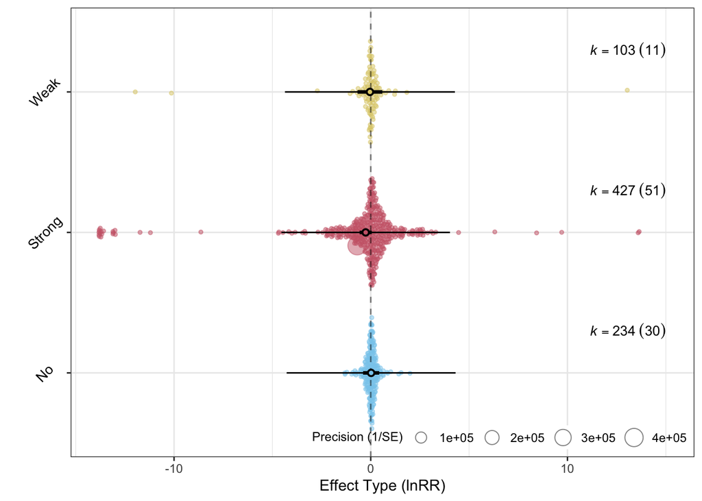

```r
orchaRd::orchard_plot(MAMET,
                      data = merged_data,
                      group = "Study",
                      mod = "Effect.type",
                      xlab = "Effect Type (lnRR)",
                      angle = 45)
```

Figure 1: Forest Plot of Effect Types of Each Study in the “Merged Data” Dataset

### Funnel plot for vi

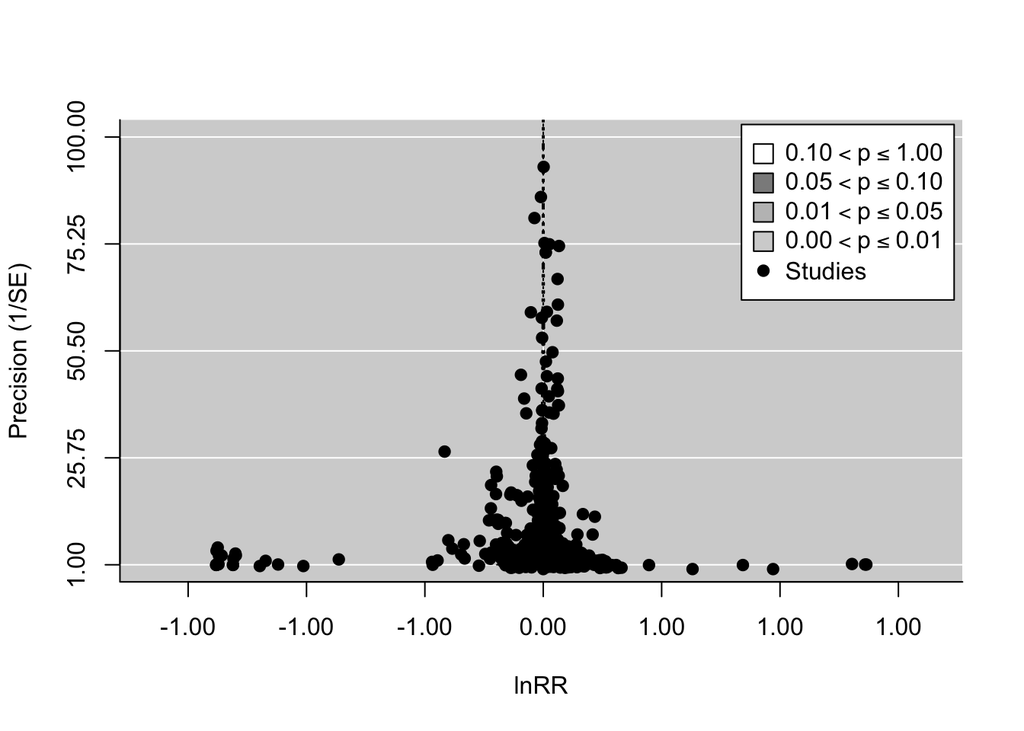

```r
metafor::funnel(x = merged_data$lnRR,
                vi = merged_data$vlnRR,
                yaxis = "seinv",
                digits = 2,
                ylim = c(1, 100),
                level = c(0.1, 0.05, 0.01),
                shade = c("white", "gray55", "gray 75"),
                atransf=tanh,
                legend = TRUE,
                ylab = "Precision (1/SE)",
                xlab = "lnRR")
```

Figure 2: Funnel Plot of The Transformed Log Ratio of Means against the Precision, with a ylim of 100 to exclude outliers.

### Time-lag plot assessing how effect sizes may or may not have changed through time. – Using Year of Print

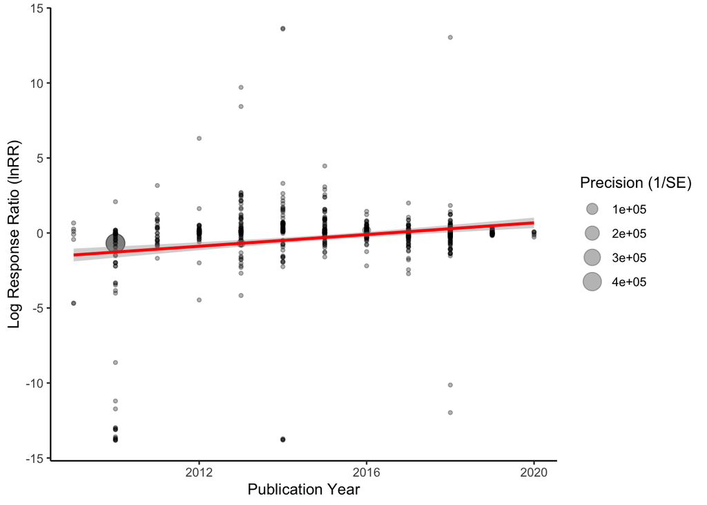

```r
ggplot(merged_data, aes(y = lnRR,
                        x = Year..print.,
                        size = 1/sqrt(vlnRR))) +
                        geom_point(alpha = 0.3) +
                        geom_smooth(method = lm,
                                    col = "red",
                                    show.legend = FALSE) +
                        labs(x = "Publication Year",
                        y = "Log Response Ratio (lnRR)",
                        size = "Precision (1/SE)") +
                        theme_classic()
```

Figure 3: Time-Lag Plot of lnRR as a function of the Publication Year.

### Formal meta-regression model that includes year as a moderator (fixed effect) to test for time-lag bias

```r
metareg_time <- rma.mv(lnRR ~ Year..print.,
                       V = vlnRR,
                       random = list(~1 | Study,
                                     ~1 | residual),
                       test = "t",
                       dfs = "contain",
                       data = merged_data)
sumtime <- summary(metareg_time)
sumtime
```

```
##
## Multivariate Meta-Analysis Model (k = 764; method: REML)
##
##     logLik    Deviance         AIC         BIC        AICc
## -1717.0859   3434.1718   3442.1718   3460.7156   3442.2246
##
## Variance Components:
##
##             estim    sqrt  nlvls  fixed    factor
## sigma^2.1  0.3797  0.6162     92     no     Study
## sigma^2.2  4.1484  2.0368    764     no  residual
##
## Test for Residual Heterogeneity:
## QE(df = 762) = 161793999.5769, p-val < .0001
##
## Test of Moderators (coefficient 2):
## F(df1 = 1, df2 = 90) = 9.2331, p-val = 0.0031
##
## Model Results:
##
##                estimate       se     tval  df    pval      ci.lb     ci.ub
## intrcpt       -259.1851  85.2481  -3.0404  90  0.0031  -428.5453  -89.8249  **
## Year..print.     0.1285   0.0423   3.0386  90  0.0031     0.0445    0.2126  **
##
## ---
## Signif. codes:  0 '***' 0.001 '**' 0.01 '*' 0.05 '.' 0.1 ' ' 1
```

Table 4: Summary of the Multivariate Meta-Analysis Model for Time-Lag Bias

```r
r2_time <- orchaRd::r2_ml(metareg_time)
r2_tib <- tibble(r2_time)
r2_tib
```

```
## # A tibble: 2 × 1
##   r2_time
##     <dbl>
## 1  0.0269
## 2  0.109
```

Table 5: Variation Explained by Time When Results were Published in lnRR